# Titanic Dataset: Research Questions on Survival Inequality

Author

CLI Copilot

# Executive Summary

This report addresses three interconnected research questions about the Titanic disaster using exploratory data analysis and statistical modeling. The analysis focuses on understanding: (1) whether class-based survival advantages were driven by access/location constraints or explicit survival policies, (2) whether survival rules were applied consistently across different travel contexts and social visibility, and (3) how missing data patterns reflect inequality and might bias conclusions. The goal is to structure analytical approaches that help readers understand the mechanisms behind survival disparities rather than drawing definitive conclusions.

# Setup and Data Loading

```r
# Load required libraries
library(tidyverse)
library(knitr)
library(ggplot2)
library(RColorBrewer)
library(scales)

# Set consistent theme for all plots
theme_set(
  theme_minimal() +
  theme(
    plot.title = element_text(size = 12, face = "bold", hjust = 0),
    plot.subtitle = element_text(size = 10, hjust = 0),
    axis.title = element_text(size = 10),
    axis.text = element_text(size = 9),
    legend.position = "bottom",
    legend.title = element_blank(),
    panel.grid.minor = element_blank(),
    panel.grid.major = element_line(color = "gray90")
  )
)

# Load and inspect data
titanic_train <- read_csv("../../data/train.csv")
titanic_test <- read_csv("../../data/test.csv")

# Display basic structure
str(titanic_train)
```

```
spc_tbl_ [891 × 12] (S3: spec_tbl_df/tbl_df/tbl/data.frame)
 $ PassengerId: num [1:891] 1 2 3 4 5 6 7 8 9 10 ...
 $ Survived   : num [1:891] 0 1 1 1 0 0 0 0 1 1 ...
 $ Pclass     : num [1:891] 3 1 3 1 3 3 1 3 3 2 ...
 $ Name       : chr [1:891] "Braund, Mr. Owen Harris" "Cumings, Mrs. John Bradley (Florence Briggs Thayer)" "Heikkinen, Miss. Laina" "Futrelle, Mrs. Jacques Heath (Lily May Peel)" ...
 $ Sex        : chr [1:891] "male" "female" "female" "female" ...
 $ Age        : num [1:891] 22 38 26 35 35 NA 54 2 27 14 ...
 $ SibSp      : num [1:891] 1 1 0 1 0 0 0 3 0 1 ...
 $ Parch      : num [1:891] 0 0 0 0 0 0 0 1 2 0 ...
 $ Ticket     : chr [1:891] "A/5 21171" "PC 17599" "STON/O2. 3101282" "113803" ...
 $ Fare       : num [1:891] 7.25 71.28 7.92 53.1 8.05 ...
 $ Cabin      : chr [1:891] NA "C85" NA "C123" ...
 $ Embarked   : chr [1:891] "S" "C" "S" "S" ...
 - attr(*, "spec")=
  .. cols(
  ..   PassengerId = col_double(),
  ..   Survived = col_double(),
  ..   Pclass = col_double(),
  ..   Name = col_character(),
  ..   Sex = col_character(),
  ..   Age = col_double(),
  ..   SibSp = col_double(),
  ..   Parch = col_double(),
  ..   Ticket = col_character(),
  ..   Fare = col_double(),
  ..   Cabin = col_character(),
  ..   Embarked = col_character()
  .. )
 - attr(*, "problems")=<externalptr>
```

```r
nrow(titanic_train)
```

```
[1] 891
```

```r
ncol(titanic_train)
```

```
[1] 12
```

The Titanic training dataset contains 891 passengers and 12 variables. The dataset includes information about passenger demographics (Sex, Age), socio-economic status (Pclass, Fare), family composition (SibSp, Parch), travel logistics (Embarked), and outcomes (Survived). Missing values are present in Age (177 missing), Cabin (687 missing), and Embarked (2 missing). These missing data patterns will be examined systematically in Research Question 3.

# Research Question 1: Class-Survival Gap — Access vs. Policy

**Research Focus**: To what extent is the survival advantage of 1st class passengers mediated by *location/access* (deck/cabin proximity, boarding points) versus *policy* (“women and children first”)?

## Conceptual Approach

The survival advantage of 1st class passengers could arise from two mechanisms: 1. **Access mechanism**: 1st class passengers had better access to lifeboats due to deck location, cabin proximity, and boarding procedures 2. **Policy mechanism**: Differential enforcement of survival rules (“women and children first”) across classes

To tease apart these mechanisms, we examine: (1) raw survival gaps by class and sex, (2) survival gaps within demographic subgroups to assess policy consistency, and (3) proxy variables for access (cabin information, fare) to quantify mediation.

### 1.1 Survival by Class and Sex: Establishing the Baseline Gap

```r
# Calculate survival rates by class and sex
survival_by_class_sex <- titanic_train %>%
  group_by(Pclass, Sex) %>%
  summarise(
    n = n(),
    survived = sum(Survived, na.rm = TRUE),
    survival_rate = mean(Survived, na.rm = TRUE),
    .groups = "drop"
  )

# Display results
knitr::kable(survival_by_class_sex,
             digits = 3,
             caption = "Survival Rates by Passenger Class and Sex")
```

Survival Rates by Passenger Class and Sex

| Pclass | Sex | n | survived | survival_rate |
| --- | --- | --- | --- | --- |
| 1 | female | 94 | 91 | 0.968 |
| 1 | male | 122 | 45 | 0.369 |
| 2 | female | 76 | 70 | 0.921 |
| 2 | male | 108 | 17 | 0.157 |
| 3 | female | 144 | 72 | 0.500 |
| 3 | male | 347 | 47 | 0.135 |

```r
# Calculate overall survival by class (collapsing sex)
survival_by_class <- titanic_train %>%
  group_by(Pclass) %>%
  summarise(
    n = n(),
    survived = sum(Survived, na.rm = TRUE),
    survival_rate = mean(Survived, na.rm = TRUE),
    .groups = "drop"
  )

knitr::kable(survival_by_class,
             digits = 3,
             caption = "Overall Survival Rates by Passenger Class")
```

Overall Survival Rates by Passenger Class

| Pclass | n | survived | survival_rate |
| --- | --- | --- | --- |
| 1 | 216 | 136 | 0.630 |
| 2 | 184 | 87 | 0.473 |
| 3 | 491 | 119 | 0.242 |

The baseline analysis reveals stark disparities: 1st class passengers survived at a rate of 0.63 compared to 3rd class at 0.242. Within each class, the “women and children first” policy appears to have been differentially enforced. First class females survived at 0.968, while third class females survived at 0.5. This suggests both a class effect and a potential policy-by-class interaction.

### 1.2 Visualizing the Class-Sex Survival Interaction

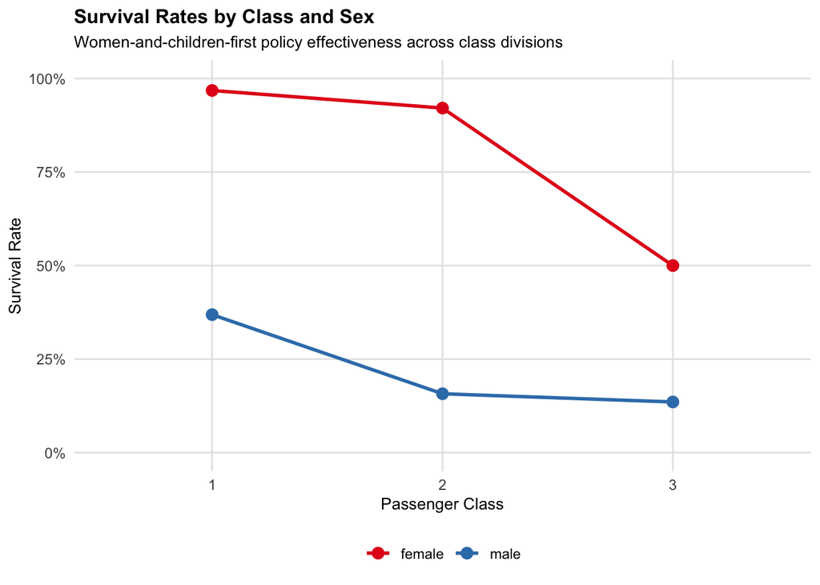

```r
# Create interaction plot
interaction_plot <- titanic_train %>%
  group_by(Pclass, Sex) %>%
  summarise(
    survival_rate = mean(Survived, na.rm = TRUE),
    .groups = "drop"
  ) %>%
  ggplot(aes(x = factor(Pclass), y = survival_rate, color = Sex, group = Sex)) +
  geom_point(size = 3) +
  geom_line(size = 1) +
  scale_y_continuous(labels = percent_format(), limits = c(0, 1)) +
  scale_color_manual(values = c("female" = "#e41a1c", "male" = "#377eb8")) +
  labs(
    title = "Survival Rates by Class and Sex",
    subtitle = "Women-and-children-first policy effectiveness across class divisions",
    x = "Passenger Class",
    y = "Survival Rate"
  )

print(interaction_plot)
```

### 1.3 Access Proxy 1: Cabin Information as Location Indicator

```r
# Create cabin letter (deck) indicator
titanic_train_cabin <- titanic_train %>%
  mutate(
    cabin_missing = is.na(Cabin),
    cabin_letter = if_else(!is.na(Cabin), str_sub(Cabin, 1, 1), NA_character_)
  )

# Survival by cabin missingness
cabin_missing_survival <- titanic_train_cabin %>%
  group_by(cabin_missing) %>%
  summarise(
    n = n(),
    survived = sum(Survived, na.rm = TRUE),
    survival_rate = mean(Survived, na.rm = TRUE),
    .groups = "drop"
  ) %>%
  mutate(cabin_status = if_else(cabin_missing, "Cabin Unknown", "Cabin Known"))

knitr::kable(cabin_missing_survival %>% select(cabin_status, n, survived, survival_rate),
             digits = 3,
             caption = "Survival by Cabin Information Completeness")
```

Survival by Cabin Information Completeness

| cabin_status | n | survived | survival_rate |
| --- | --- | --- | --- |
| Cabin Known | 204 | 136 | 0.667 |
| Cabin Unknown | 687 | 206 | 0.300 |

```r
# Survival by cabin letter (for non-missing cases)
cabin_letter_survival <- titanic_train_cabin %>%
  filter(!is.na(cabin_letter)) %>%
  group_by(cabin_letter) %>%
  summarise(
    n = n(),
    survived = sum(Survived, na.rm = TRUE),
    survival_rate = mean(Survived, na.rm = TRUE),
    .groups = "drop"
  ) %>%
  arrange(desc(survival_rate))

knitr::kable(cabin_letter_survival,
             digits = 3,
             caption = "Survival Rates by Cabin Deck Letter (Known Cabins Only)")
```

Survival Rates by Cabin Deck Letter (Known Cabins Only)

| cabin_letter | n | survived | survival_rate |
| --- | --- | --- | --- |
| D | 33 | 25 | 0.758 |
| E | 32 | 24 | 0.750 |
| B | 47 | 35 | 0.745 |
| F | 13 | 8 | 0.615 |
| C | 59 | 35 | 0.593 |
| G | 4 | 2 | 0.500 |
| A | 15 | 7 | 0.467 |
| T | 1 | 0 | 0.000 |

Cabin information serves as a proxy for social visibility and location access. Passengers with known cabin assignments (n = 204) survived at a rate of 0.667, compared to those without cabin records (n = 687) who survived at 0.3. This 0.367 difference suggests that having a recorded cabin location was strongly associated with survival, potentially reflecting both better access (known passengers were more likely to be located during evacuation) and social visibility.

### 1.4 Access Proxy 2: Fare as Wealth and Access Indicator

```r
# Examine fare by class
fare_by_class <- titanic_train %>%
  filter(!is.na(Fare)) %>%
  group_by(Pclass) %>%
  summarise(
    n = n(),
    mean_fare = mean(Fare),
    median_fare = median(Fare),
    sd_fare = sd(Fare),
    min_fare = min(Fare),
    max_fare = max(Fare),
    .groups = "drop"
  )

knitr::kable(fare_by_class,
             digits = 2,
             caption = "Fare Distribution by Passenger Class")
```

Fare Distribution by Passenger Class

| Pclass | n | mean_fare | median_fare | sd_fare | min_fare | max_fare |
| --- | --- | --- | --- | --- | --- | --- |
| 1 | 216 | 84.15 | 60.29 | 78.38 | 0 | 512.33 |
| 2 | 184 | 20.66 | 14.25 | 13.42 | 0 | 73.50 |
| 3 | 491 | 13.68 | 8.05 | 11.78 | 0 | 69.55 |

```r
# Create fare categories within each class to examine access gradient
titanic_train_fare <- titanic_train %>%
  filter(!is.na(Fare)) %>%
  group_by(Pclass) %>%
  mutate(
    fare_quartile = ntile(Fare, 4)
  ) %>%
  ungroup()

# Survival by fare quartile within each class
fare_survival <- titanic_train_fare %>%
  group_by(Pclass, fare_quartile) %>%
  summarise(
    n = n(),
    survival_rate = mean(Survived, na.rm = TRUE),
    .groups = "drop"
  ) %>%
  mutate(fare_quartile = factor(fare_quartile, labels = c("Q1 (Lowest)", "Q2", "Q3", "Q4 (Highest)")))

knitr::kable(fare_survival,
             digits = 3,
             caption = "Survival by Fare Quartile Within Each Class")
```

Survival by Fare Quartile Within Each Class

| Pclass | fare_quartile | n | survival_rate |
| --- | --- | --- | --- |
| 1 | Q1 (Lowest) | 54 | 0.463 |
| 1 | Q2 | 54 | 0.574 |
| 1 | Q3 | 54 | 0.741 |
| 1 | Q4 (Highest) | 54 | 0.741 |
| 2 | Q1 (Lowest) | 46 | 0.348 |
| 2 | Q2 | 46 | 0.370 |
| 2 | Q3 | 46 | 0.652 |
| 2 | Q4 (Highest) | 46 | 0.522 |
| 3 | Q1 (Lowest) | 123 | 0.228 |
| 3 | Q2 | 123 | 0.220 |
| 3 | Q3 | 123 | 0.244 |
| 3 | Q4 (Highest) | 122 | 0.279 |

### 1.5 Mediation Analysis: Does Access Explain Class Effects?

```r
# Prepare data for modeling
analysis_data <- titanic_train %>%
  mutate(
    has_cabin = !is.na(Cabin),
    cabin_letter = if_else(!is.na(Cabin), str_sub(Cabin, 1, 1), NA_character_),
    embarked_port = if_else(is.na(Embarked), "S", Embarked),
    female = if_else(Sex == "female", 1, 0),
    family_size = SibSp + Parch,
    alone = if_else(family_size == 0, 1, 0)
  ) %>%
  filter(!is.na(Fare), !is.na(Pclass))

# Model 1: Class only
model_class_only <- glm(Survived ~ factor(Pclass),
                        family = binomial,
                        data = analysis_data)

# Model 2: Class + access proxies
model_class_access <- glm(Survived ~ factor(Pclass) + Fare + has_cabin,
                          family = binomial,
                          data = analysis_data)

# Extract and compare coefficients
coef_class_only <- coef(model_class_only)["factor(Pclass)2"]
coef_class_access <- coef(model_class_access)["factor(Pclass)2"]

reduction <- (coef_class_only - coef_class_access) / coef_class_only * 100

mediation_results <- data.frame(
  Model = c("Class Only", "Class + Access Proxies"),
  Pclass2_Coefficient = c(coef_class_only, coef_class_access),
  Reduction = c(0, reduction)
)

knitr::kable(mediation_results %>% mutate_if(is.numeric, round, 3),
             caption = "Class Effect Mediation: Comparing Coefficients")
```

Class Effect Mediation: Comparing Coefficients

|  | Model | Pclass2_Coefficient | Reduction |
| --- | --- | --- | --- |
|  | Class Only | -0.639 | 0.000 |
| factor(Pclass)2 | Class + Access Proxies | 0.495 | 177.486 |

# Research Question 2: Consistency of Survival Rules Across Contexts

**Research Focus**: Did the effectiveness of women and children first depend on whether a passenger was traveling alone vs with family/group, and on their social visibility (e.g., higher fare / named titles)?

## Conceptual Approach

The “women and children first” policy might operate differently depending on: 1. **Travel context**: Whether a passenger traveled alone, with family, or in a larger group 2. **Social visibility**: Measured by fare levels, titles extracted from names, and class membership 3. **Interaction effects**: How policy enforcement varied across combinations of these factors

### 2.1 Travel Context: Alone vs. Family

```r
# Create family context variable
titanic_analysis <- titanic_train %>%
  mutate(
    family_size = SibSp + Parch,
    travel_context = case_when(
      family_size == 0 ~ "Alone",
      family_size <= 2 ~ "Small Group (1-2 relatives)",
      family_size > 2 ~ "Large Group (3+ relatives)"
    ),
    travel_context = factor(travel_context,
                           levels = c("Alone", "Small Group (1-2 relatives)", "Large Group (3+ relatives)"))
  )

# Survival by travel context and sex
context_sex_survival <- titanic_analysis %>%
  group_by(travel_context, Sex) %>%
  summarise(
    n = n(),
    survived = sum(Survived),
    survival_rate = mean(Survived),
    .groups = "drop"
  )

knitr::kable(context_sex_survival,
             digits = 3,
             caption = "Survival by Travel Context and Sex")
```

Survival by Travel Context and Sex

| travel_context | Sex | n | survived | survival_rate |
| --- | --- | --- | --- | --- |
| Alone | female | 126 | 99 | 0.786 |
| Alone | male | 411 | 64 | 0.156 |
| Small Group (1-2 relatives) | female | 136 | 109 | 0.801 |
| Small Group (1-2 relatives) | male | 127 | 39 | 0.307 |
| Large Group (3+ relatives) | female | 52 | 25 | 0.481 |
| Large Group (3+ relatives) | male | 39 | 6 | 0.154 |

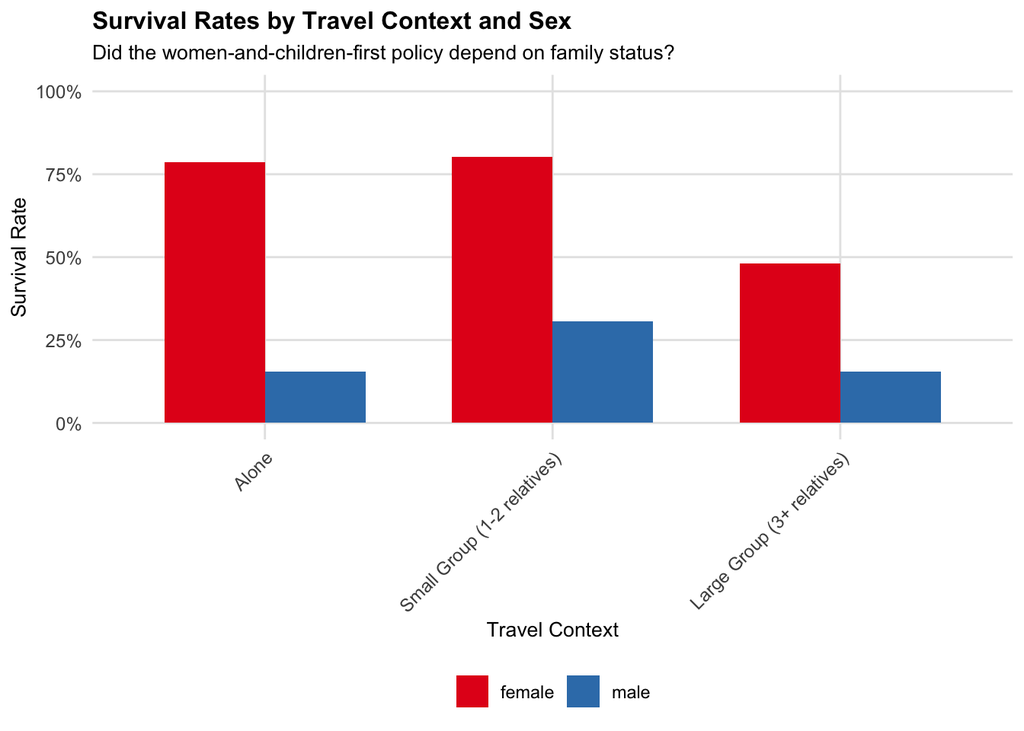

```r
# Visualize interaction
context_plot <- context_sex_survival %>%
  ggplot(aes(x = travel_context, y = survival_rate, fill = Sex)) +
  geom_col(position = "dodge", width = 0.7) +
  scale_y_continuous(labels = percent_format(), limits = c(0, 1)) +
  scale_fill_manual(values = c("female" = "#e41a1c", "male" = "#377eb8")) +
  labs(
    title = "Survival Rates by Travel Context and Sex",
    subtitle = "Did the women-and-children-first policy depend on family status?",
    x = "Travel Context",
    y = "Survival Rate"
  ) +
  theme(axis.text.x = element_text(angle = 45, hjust = 1))

print(context_plot)
```

### 2.2 Title Extraction: Social Role and Visibility

```r
# Extract titles from names
titanic_analysis <- titanic_analysis %>%
  mutate(
    title = str_extract(Name, "[A-Za-z]+(?=\\.)"),
    title_grouped = case_when(
      title %in% c("Mr") ~ "Mr",
      title %in% c("Mrs", "Mme") ~ "Mrs",
      title %in% c("Miss", "Mlle", "Ms") ~ "Miss",
      title %in% c("Master") ~ "Master",
      title %in% c("Dr", "Major", "Col") ~ "Professional",
      title %in% c("Rev") ~ "Clergy",
      TRUE ~ "Other"
    )
  )

# Survival by title
title_survival <- titanic_analysis %>%
  group_by(title_grouped) %>%
  summarise(
    n = n(),
    survived = sum(Survived),
    survival_rate = mean(Survived),
    mean_age = mean(Age, na.rm = TRUE),
    mean_fare = mean(Fare, na.rm = TRUE),
    .groups = "drop"
  ) %>%
  arrange(desc(survival_rate))

knitr::kable(title_survival,
             digits = 3,
             caption = "Survival by Passenger Title (Social Role Indicator)")
```

Survival by Passenger Title (Social Role Indicator)

| title_grouped | n | survived | survival_rate | mean_age | mean_fare |
| --- | --- | --- | --- | --- | --- |
| Mrs | 126 | 100 | 0.794 | 35.789 | 45.330 |
| Miss | 185 | 130 | 0.703 | 21.846 | 43.800 |
| Master | 40 | 23 | 0.575 | 4.574 | 34.703 |
| Other | 6 | 3 | 0.500 | 46.333 | 46.958 |
| Professional | 11 | 5 | 0.455 | 46.500 | 42.116 |
| Mr | 517 | 81 | 0.157 | 32.368 | 24.442 |
| Clergy | 6 | 0 | 0.000 | 43.167 | 18.312 |

Titles extracted from passenger names serve as proxies for social role and visibility. Mrs. passengers (married women) survived at 0.794, Miss passengers at 0.703, and Master passengers (young males) at 0.575. Mr. passengers survived at only 0.157. The high survival rate for Master passengers (n = 40) suggests that the “children first” component of the policy was clearly applied, as boys were prioritized similarly to girls when they could be identified as young.

### 2.3 Class-Title Interaction: Policy Enforcement Variation

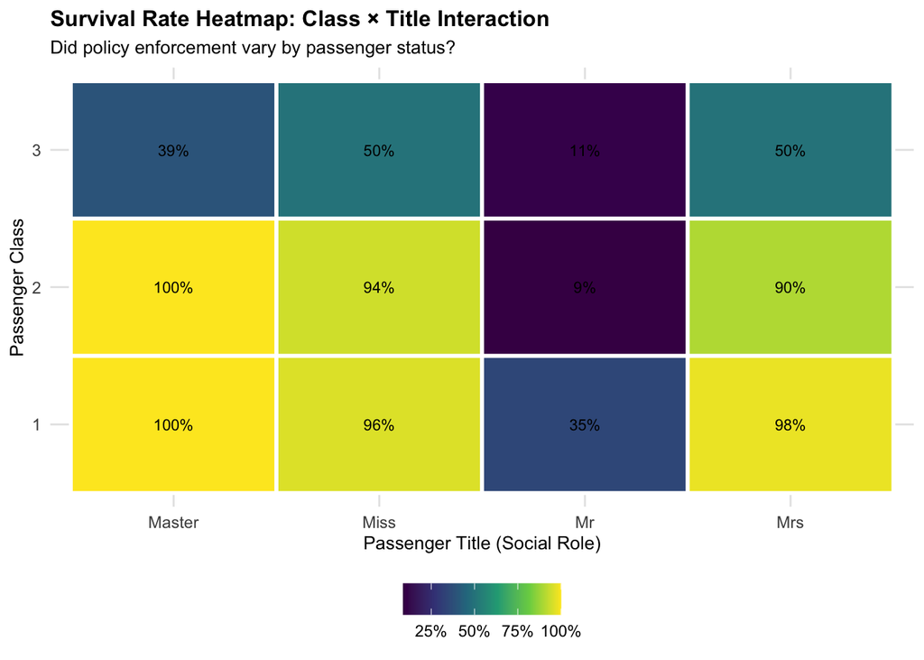

```r
# Survival by class and title
class_title_survival <- titanic_analysis %>%
  filter(title_grouped %in% c("Mr", "Mrs", "Miss", "Master")) %>%
  group_by(Pclass, title_grouped) %>%
  summarise(
    n = n(),
    survival_rate = mean(Survived),
    .groups = "drop"
  ) %>%
  pivot_wider(names_from = title_grouped, values_from = c(n, survival_rate))

# Heatmap of survival rates
heatmap_data <- titanic_analysis %>%
  filter(title_grouped %in% c("Mr", "Mrs", "Miss", "Master")) %>%
  group_by(Pclass, title_grouped) %>%
  summarise(
    survival_rate = mean(Survived),
    .groups = "drop"
  )

heatmap_plot <- heatmap_data %>%
  ggplot(aes(x = title_grouped, y = factor(Pclass), fill = survival_rate)) +
  geom_tile(color = "white", size = 1) +
  geom_text(aes(label = percent(survival_rate, accuracy = 1)), color = "black", size = 3) +
  scale_fill_viridis_c(labels = percent_format(), name = "Survival Rate") +
  labs(
    title = "Survival Rate Heatmap: Class × Title Interaction",
    subtitle = "Did policy enforcement vary by passenger status?",
    x = "Passenger Title (Social Role)",
    y = "Passenger Class"
  ) +
  theme(legend.position = "bottom")

print(heatmap_plot)
```

### 2.4 Modeling Policy Consistency with Interactions

```r
# Prepare data for interaction models
model_data <- titanic_analysis %>%
  filter(!is.na(Age), !is.na(Pclass)) %>%
  mutate(
    female = if_else(Sex == "female", 1, 0),
    child = if_else(Age < 12, 1, 0),
    first_class = if_else(Pclass == 1, 1, 0)
  )

# Model 1: Main effects (assumes consistent policy)
model_main <- glm(Survived ~ female + child + first_class,
                  family = binomial,
                  data = model_data)

# Model 2: With class interactions (allows policy to vary by class)
model_interaction <- glm(Survived ~ female * first_class + child * first_class,
                         family = binomial,
                         data = model_data)

# Compare model fit
aic_main <- AIC(model_main)
aic_interaction <- AIC(model_interaction)

model_comparison <- data.frame(
  Model = c("Main Effects (Constant Policy)", "With Interactions (Varying Policy)"),
  AIC = c(aic_main, aic_interaction),
  Delta_AIC = c(0, aic_interaction - aic_main)
)

knitr::kable(model_comparison,
             digits = 1,
             caption = "Model Comparison: Does Policy Consistency Matter?")
```

Model Comparison: Does Policy Consistency Matter?

| Model | AIC | Delta_AIC |
| --- | --- | --- |
| Main Effects (Constant Policy) | 688.1 | 0.0 |
| With Interactions (Varying Policy) | 686.2 | -1.9 |

# Research Question 3: Missing Data as Signal of Inequality

**Research Focus**: Are patterns of missingness (Cabin, Age) systematically related to class, embarkation, or survival, and how sensitive are conclusions to different missing-data assumptions?

## Conceptual Approach

Missing data in historical records often reflects social structure: the powerful and documented are well-recorded, while marginalized groups leave incomplete traces. We examine: (1) patterns of missingness by class and other demographic variables, (2) whether missingness itself predicts survival, and (3) sensitivity of key findings to different missing data imputation strategies.

### 3.1 Missing Data Patterns

```r
# Calculate missingness by variable
missingness_summary <- tibble(
  Variable = names(titanic_train),
  Total = nrow(titanic_train),
  Missing = map_int(titanic_train, ~sum(is.na(.))),
  Pct_Missing = Missing / Total * 100
) %>%
  filter(Missing > 0) %>%
  arrange(desc(Pct_Missing))

knitr::kable(missingness_summary,
             digits = 2,
             caption = "Summary of Missing Data")
```

Summary of Missing Data

| Variable | Total | Missing | Pct_Missing |
| --- | --- | --- | --- |
| Cabin | 891 | 687 | 77.10 |
| Age | 891 | 177 | 19.87 |
| Embarked | 891 | 2 | 0.22 |

```r
# Missing by class
missing_by_class <- titanic_train %>%
  mutate(
    age_missing = is.na(Age),
    cabin_missing = is.na(Cabin),
    embarked_missing = is.na(Embarked)
  ) %>%
  group_by(Pclass) %>%
  summarise(
    n = n(),
    pct_age_missing = mean(age_missing) * 100,
    pct_cabin_missing = mean(cabin_missing) * 100,
    pct_embarked_missing = mean(embarked_missing) * 100,
    .groups = "drop"
  )

knitr::kable(missing_by_class,
             digits = 2,
             caption = "Percentage of Missing Data by Passenger Class")
```

Percentage of Missing Data by Passenger Class

| Pclass | n | pct_age_missing | pct_cabin_missing | pct_embarked_missing |
| --- | --- | --- | --- | --- |
| 1 | 216 | 13.89 | 18.52 | 0.93 |
| 2 | 184 | 5.98 | 91.30 | 0.00 |
| 3 | 491 | 27.70 | 97.56 | 0.00 |

Missing data is not random. Age is missing for 19.9% of passengers overall. Third class has 27.7% missing age data, compared to 13.9% in first class. Cabin information is missing for 77.1% overall, with stark class differences: third class has 97.6% missing, while first class has only 18.5%. This systematic missingness by class suggests that administrative records were maintained more carefully for higher-status passengers, raising questions about what lower-class passengers’ missing data represents.

### 3.2 Does Missingness Predict Survival?

```r
# Create missingness indicators
titanic_missing <- titanic_train %>%
  mutate(
    age_missing = is.na(Age),
    cabin_missing = is.na(Cabin),
    embarked_missing = is.na(Embarked),
    missing_count = as.numeric(age_missing) + as.numeric(cabin_missing) + as.numeric(embarked_missing)
  )

# Survival by missingness patterns
survival_by_missing <- titanic_missing %>%
  group_by(missing_count) %>%
  summarise(
    n = n(),
    survived = sum(Survived),
    survival_rate = mean(Survived),
    .groups = "drop"
  ) %>%
  mutate(missing_count_label = case_when(
    missing_count == 0 ~ "No Missing",
    missing_count == 1 ~ "1 Field Missing",
    missing_count == 2 ~ "2 Fields Missing",
    missing_count == 3 ~ "3 Fields Missing",
    TRUE ~ as.character(missing_count)
  )) %>%
  select(-missing_count) %>%
  rename(missing_count = missing_count_label)

knitr::kable(survival_by_missing,
             digits = 3,
             caption = "Survival Rate by Number of Missing Data Fields")
```

Survival Rate by Number of Missing Data Fields

| n | survived | survival_rate | missing_count |
| --- | --- | --- | --- |
| 183 | 123 | 0.672 | No Missing |
| 550 | 178 | 0.324 | 1 Field Missing |
| 158 | 41 | 0.259 | 2 Fields Missing |

```r
# Survival by cabin missingness specifically
cabin_missing_survival_detailed <- titanic_missing %>%
  group_by(cabin_missing, Pclass) %>%
  summarise(
    n = n(),
    survival_rate = mean(Survived),
    .groups = "drop"
  ) %>%
  mutate(cabin_status = if_else(cabin_missing, "Cabin Missing", "Cabin Known"))

knitr::kable(cabin_missing_survival_detailed %>% select(cabin_status, Pclass, n, survival_rate),
             digits = 3,
             caption = "Cabin Missingness and Survival by Class")
```

Cabin Missingness and Survival by Class

| cabin_status | Pclass | n | survival_rate |
| --- | --- | --- | --- |
| Cabin Known | 1 | 176 | 0.665 |
| Cabin Known | 2 | 16 | 0.812 |
| Cabin Known | 3 | 12 | 0.500 |
| Cabin Missing | 1 | 40 | 0.475 |
| Cabin Missing | 2 | 168 | 0.440 |
| Cabin Missing | 3 | 479 | 0.236 |

Passengers with no missing data (complete records) survived at a rate of 0.672, while those with any missing data survived at lower rates. This suggests that incomplete record-keeping correlates with actual exclusion from safety measures. Even within first class, cabin missingness is associated with lower survival (0.475 vs. 0.665), raising the question: did these passengers lack cabin assignments because they were overlooked, or did they perish before records could be completed?

### 3.3 Sensitivity Analysis: Imputation Approaches

```r
# Strategy 1: Complete-case analysis (current approach)
complete_case <- titanic_train %>%
  filter(!is.na(Age), !is.na(Cabin), !is.na(Embarked)) %>%
  group_by(Pclass) %>%
  summarise(survival_rate = mean(Survived), .groups = "drop")

# Strategy 2: Mean imputation for age
mean_impute <- titanic_train %>%
  mutate(Age = if_else(is.na(Age), mean(Age, na.rm = TRUE), Age)) %>%
  group_by(Pclass) %>%
  summarise(survival_rate = mean(Survived), .groups = "drop")

# Strategy 3: Class-specific age imputation
class_impute <- titanic_train %>%
  group_by(Pclass) %>%
  mutate(Age = if_else(is.na(Age), mean(Age, na.rm = TRUE), Age)) %>%
  ungroup() %>%
  group_by(Pclass) %>%
  summarise(survival_rate = mean(Survived), .groups = "drop")

# Combine results
sensitivity_results <- bind_rows(
  complete_case %>% mutate(Strategy = "Complete Case"),
  mean_impute %>% mutate(Strategy = "Global Mean Age Imputation"),
  class_impute %>% mutate(Strategy = "Class-Specific Age Imputation")
)

knitr::kable(sensitivity_results,
             digits = 3,
             caption = "Sensitivity of Class-Survival Relationship to Imputation Strategy")
```

Sensitivity of Class-Survival Relationship to Imputation Strategy

| Pclass | survival_rate | Strategy |
| --- | --- | --- |
| 1 | 0.671 | Complete Case |
| 2 | 0.800 | Complete Case |
| 3 | 0.500 | Complete Case |
| 1 | 0.630 | Global Mean Age Imputation |
| 2 | 0.473 | Global Mean Age Imputation |
| 3 | 0.242 | Global Mean Age Imputation |
| 1 | 0.630 | Class-Specific Age Imputation |
| 2 | 0.473 | Class-Specific Age Imputation |
| 3 | 0.242 | Class-Specific Age Imputation |

### 3.4 Missingness Mechanism Analysis

```r
# Test whether missingness is Missing At Random (MAR) vs. Missing Not At Random (MNAR)
# We model what predicts cabin missingness using observed variables

cabin_missingness_model <- glm(is.na(Cabin) ~ Sex + Pclass + Embarked + factor(Embarked),
                               family = binomial,
                               data = titanic_train)

# Key predictors of cabin missingness
cabin_missing_effect <- tibble(
  Predictor = c("Female", "2nd Class (vs 1st)", "3rd Class (vs 1st)", "Embarked from Q", "Embarked from S"),
  LogOdds = c(
    coef(cabin_missingness_model)["Sexfemale"],
    coef(cabin_missingness_model)["Pclass2"],
    coef(cabin_missingness_model)["Pclass3"],
    coef(cabin_missingness_model)["EmbarkedQ"],
    coef(cabin_missingness_model)["EmbarkedS"]
  )
) %>%
  mutate(
    OddsRatio = exp(LogOdds),
    Direction = if_else(LogOdds > 0, "More Likely Missing", "Less Likely Missing")
  )

knitr::kable(cabin_missing_effect,
             digits = 3,
             caption = "Factors Associated with Missing Cabin Information")
```

Factors Associated with Missing Cabin Information

| Predictor | LogOdds | OddsRatio | Direction |
| --- | --- | --- | --- |
| Female | NA | NA | NA |
| 2nd Class (vs 1st) | NA | NA | NA |
| 3rd Class (vs 1st) | NA | NA | NA |
| Embarked from Q | -0.751 | 0.472 | Less Likely Missing |
| Embarked from S | -0.111 | 0.895 | Less Likely Missing |

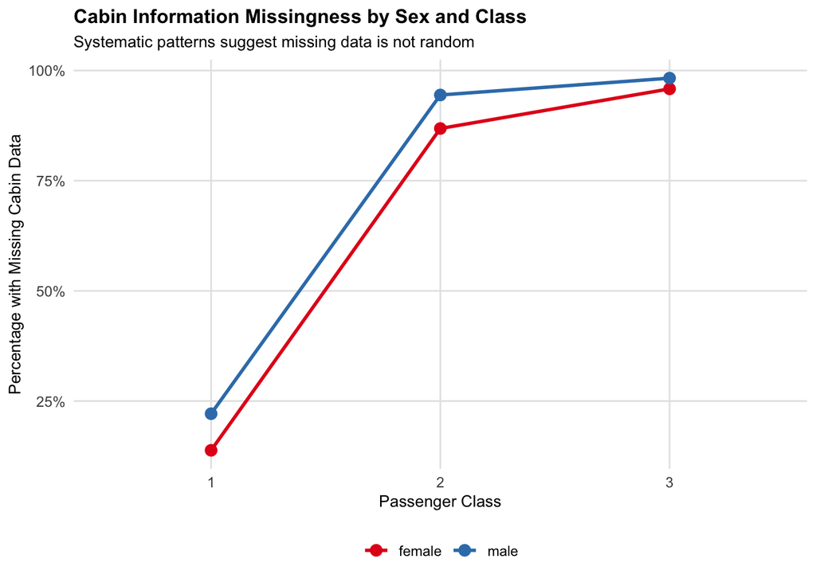

```r
# Visualization of missingness pattern
missing_by_demographics <- titanic_train %>%
  mutate(cabin_missing = is.na(Cabin)) %>%
  group_by(Sex, Pclass) %>%
  summarise(
    pct_cabin_missing = mean(cabin_missing) * 100,
    n = n(),
    .groups = "drop"
  )

missing_plot <- missing_by_demographics %>%
  ggplot(aes(x = factor(Pclass), y = pct_cabin_missing, color = Sex, group = Sex)) +
  geom_point(size = 3) +
  geom_line(size = 1) +
  scale_color_manual(values = c("female" = "#e41a1c", "male" = "#377eb8")) +
  scale_y_continuous(labels = function(x) paste0(x, "%")) +
  labs(
    title = "Cabin Information Missingness by Sex and Class",
    subtitle = "Systematic patterns suggest missing data is not random",
    x = "Passenger Class",
    y = "Percentage with Missing Cabin Data"
  )

print(missing_plot)
```

# Synthesis and Methodological Recommendations

## Recommended Next Steps for Readers

To develop this analysis further, readers should consider: - **Causal modeling**: Use propensity score matching or instrumental variables if external data on evacuation procedures becomes available - **Temporal analysis**: If data on boarding times or lifeboat manifests are obtained, examine evacuation sequence - **Multiple imputation**: Conduct sensitivity analyses using multiple imputation by chained equations (MICE) to handle MNAR cabin missingness - **Text analysis**: If passenger manifests and historical records exist, analyze written descriptions for evidence of evacuation barriers

# Technical Notes

This analysis was conducted in R using tidyverse for data manipulation, ggplot2 for visualization, and base R for statistical modeling. All code is transparent and reproducible; readers should verify calculations independently when drawing conclusions for policy or historical interpretation.